# WIP

JJayes

16/03/2022

# What extent of the Swedish labour market do Arbetsformedling’s job ads cover?

We want to know whether the job ads on Arbetsförmedlingen’s Platsbanken are representative of the entire Swedish labour market.

One way to establish this we can look at another source of job data in Sweden and compare the contents of these.

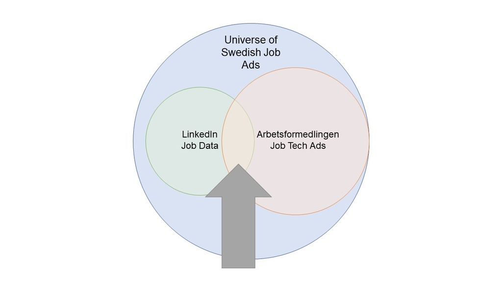

Overlap in job data

## Data sources

We will use data from the social networking site [LinkedIn](https://www.linkedin.com/). There are two sources of information that we will examine, the first is focussed on Sweden specifically, while the second is aggregated data from all of the countries in which LinkedIn operates. The first source is called the [LinkedIn Jobs on the Rise 2022 Report](https://www.linkedin.com/pulse/linkedin-jobs-rise-2022-10-roles-growing-demand-sweden-/) covering the 10 roles that are growing fastest in demand in Sweden. The second is called [Industry Jobs and Skills Trends](https://linkedindata.worldbank.org/data) produced by the [World Bank LinkedIn Digital Data for Development](https://linkedindata.worldbank.org/data) project.

## Jobs on the Rise

This first report measures the job titles “experiencing the highest growth rates from January 2017 through July 2021” in Sweden. It also provides information about the people who fill jobs with these titles currently, based on the information on LinkedIn.

### What are the fastest growing jobs?

The report states that these 10 are the fastest growing jobs in Sweden, as measured by LinkedIn.

| Rank | Title |
| --- | --- |
| 1 | Talent Acquisition Specialist |
| 2 | Business Development Representative |
| 3 | Data Engineer |
| 4 | Career Counsellor |
| 5 | Machine Learning Engineer |
| 6 | Content Coordinator |
| 7 | Back End Developer |
| 8 | Software Account Executive |
| 9 | Sustainability Manager |
| 10 | Digital Manager |

### What are skills for these jobs?

The table below shows the top skills for these jobs as recorded on LinkedIn. It is worth noting that language skills do not appear in any of these occupations. Perhaps it is widely understood that these jobs require a command of both Swedish and English.

| Rank | Title | Skill_1 | Skill_2 | Skill_3 |
| --- | --- | --- | --- | --- |
| 1 | Talent Acquisition Specialist | Employer Branding | Recruiting | Sourcing |
| 2 | Business Development Representative | Business-to-Business (B2B) | Sales | Software as a Service (SaaS) |
| 3 | Data Engineer | Data Engineering | Apache Spark | Scala |
| 4 | Career Counsellor | Coaching | Career Development | Organisational Development |
| 5 | Machine Learning Engineer | Machine Learning | TensorFlow | Deep Learning |
| 6 | Content Coordinator | Copywriting | Digital Marketing | Social Media |
| 7 | Back End Developer | Git | Docker Products | Amazon Web Services (AWS) |
| 8 | Software Account Executive | Solution Selling | Software as a Service (SaaS) | Enterprise Software |
| 9 | Sustainability Manager | Sustainable Development | Sustainability Reporting | Corporate Social Responsibility |
| 10 | Digital Manager | Digital Strategy | Google Analytics | Digital Marketing |

The lack of language skills might also be a function of the way that the top skills are identified. The methodology section of the Jobs on the Rise report is not very informative about how the top skills are mined, but in the methodology section of the LinkedIn and Worldbank data which we look to next, it states that:

> [Industry skills] are calculated using an adapted version of a text mining technique called Term Frequency - Inverse Document Frequency (TF-IDF). This method gives more weight to a skill for an industry if more members in the industry list the skill on their profiles and the skill is more unique to the industry.

*Source: [“World Bank LinkedIn Digital Data for Development” by World Bank Group & LinkedIn Corporation](https://linkedindata.worldbank.org/data)*

In other words, if the skills “English” and “Swedish” appear as skills across many jobs, these terms will not occur in the top skills for these 10 fastest growing jobs because they are not *specific* to these jobs.

In order to better compare the LinkedIn data on Sweden and Arbetsförmedlingen data, it might be worth replicating the process to find the fastest growing job vacancies in Arbetsförmedlingen’s data and looking at the skills most specific to these jobs.

### What else can we learn from the Jobs on the Rise data?

### What share of these jobs are filled by women?

Mouse over the figure below to see exactly what share of jobs are filled by men and women amongst Sweden’s fastest growing jobs according to the Jobs on the Rise report.

[interactive chart not shown]

### Experience and remote share

The Jobs on the Rise report also includes information on the attributes of the incumbents in these roles. It includes the median years of experience listed on LinkedIn, as well as the share of jobs which are done remotely.

Mouse over the dots to see the values in each tab.

#### Experience

What is the distribution of experience by job?

[interactive chart not shown]

We can see that there is a large jump in median years of experience from the second most, Digital Managers (8.7), to Software Account Executives (14.4). In addition, Machine Learning Engineers have the fewest years of experience (3.5).

#### Remote share

What is the share of jobs done remotely?

[interactive chart not shown]

It is interesting that Software Account Executives both have the greatest number of years of experience and th largest share of jobs that are conducted remotely. The next panel explores the correlation across these 10 fastest growing jobs.

Career Counsellors are almost exclusively in-person jobs, perhaps due to the nature of their work.

#### Correlation

Is there a relationship between median experience and remote share?

[interactive chart not shown]

What about a linear regression?

| **Characteristic** | **Beta**<sup>1</sup> | **SE**<sup>2</sup> |
| --- | --- | --- |
| experience | 0.01 | 0.008 |

<sup>*1*</sup> *p<0.05; **p<0.01; ***p<0.001 <sup>*2*</sup> SE = Standard Error

Wow! There is a really poor fit!

### Where are these rising jobs located?

The report also lists the three top hiring locations for these rising jobs. The list is dominated by Sweden’s three largest cities: Stockholm, Gothenburg and Malmö. Aside from these, Uppsala, Täby and Lund appear on the list.

Click on a bubble to see the jobs for which the city is amongst the three top hiring locations.

[interactive chart not shown]

### Transitions

We can also see job titles that the incumbents in these 10 fast growing jobs held prior to their current roles. These are shown in the table below.

| rank | title | top_roles_transitioned_from |
| --- | --- | --- |
| 1 | Talent Acquisition Specialist | Recruiter, Recruitment Consultant, Technical Recruiter |
| 2 | Business Development Representative | Salesperson, Account Manager, Sales Specialist |
| 3 | Data Engineer | Software Engineer, Data Scientist, Business Intelligence Consultant |
| 4 | Career Counsellor | Guidance Counsellor, Teacher, Salesperson |
| 5 | Machine Learning Engineer | Data Scientist, Software Engineer, Data Engineer |
| 6 | Content Coordinator | Content Manager, Project Manager, Copywriter |
| 7 | Back End Developer | Software Engineer, Full Stack Engineer, Web Developer |
| 8 | Software Account Executive | Account Manager, Account Executive, Sales Manager |
| 9 | Sustainability Manager | Project Manager, Environment, Health and Safety Manager, Environmental Coordinator |
| 10 | Digital Manager | Project Manager, Digital Marketing Specialist, Account Manager |

### Methodology

The methodology section of the report states that:

> LinkedIn Economic Graph researchers examined millions of jobs started by LinkedIn members from 1 January 2017 to 31 July 2021 to calculate a growth rate for each job title. To be ranked, a job title needed to see consistent growth across our membership base, as well as have grown to a meaningful size by 2021. Identical job titles across different seniority levels were grouped and ranked together. Internships, volunteer positions, interim roles and student roles were excluded, and jobs where hiring was dominated by a small handful of companies in each country were also excluded.

## LinkedIn World Bank data

The second source of data is a collaboration between LinkedIn and the World Bank, and includes four different sections. This source provides data on:

| sections | descriptions |
| --- | --- |
| Industry skill needs | The Industry Skills Needs metric captures which skills are most likely to be added to a member's profile in one industry compared to other industries |
| Skill pentration | The Skill Penetration metric looks at how many skills from each of LinkedIn's skill groups appear among the top 30 skills for each occupation in an industry |
| Industry employment shifs | The Growth from Industry Transitions metric looks at how LinkedIn members are moving across industries |
| Talent migration | The Talent Migration metrics measure arrivals minus departures in a country, sliced by source and destination, industry, and skill. |

### Industry skill needs

The table below shows the industry and sectors which list the Foreign Language as an important skill, across all of the countries in which LinkedIn operates. Translation & Localization within the sector Professional scientific and technical activities has the highest ranking of foreign language skills as a top skill, at 4. The next highest is animation, within sector Arts, entertainment and recreation at 5.

#### Industry and sectors ranking 'Foreign Language' amongst top skills

| Sector | Industry | Skill group rank |
| --- | --- | --- |
| Professional scientific and technical activities | Translation & Localization | 4 |
| Professional scientific and technical activities | Executive Office | 10 |
| Manufacturing | Automotive | 9 |
| Manufacturing | Textiles | 7 |
| Manufacturing | Paper & Forest Products | 10 |
| Manufacturing | Packaging & Containers | 10 |
| Information and communication | Computer Hardware | 10 |
| Information and communication | Internet | 10 |
| Information and communication | Semiconductors | 9 |
| Information and communication | Motion Pictures & Film | 9 |

[output cut: 15 more lines]

### Where do Sweden’s leavers go? Where do workers come to Sweden from?

[interactive chart not shown]

### What has happenned to employment growth in Sweden?

Mouse over the columns to see the rate of employment growth between 2017 and 2019 in Sweden.

#### Arts

Plot of employment growth in **Arts, entertainment and recreation**

[interactive chart not shown]

#### Financial

Plot of employment growth in **Financial and insurance activities**

[interactive chart not shown]

#### Information

Plot of employment growth in **Information and communication**

[interactive chart not shown]

#### Manufacturing

Plot of employment growth in **Manufacturing**

[interactive chart not shown]

#### Mining

Plot of employment growth in **Mining and quarrying**

[interactive chart not shown]

#### Professional

Plot of employment growth in **Professional scientific and technical activities**

[interactive chart not shown]

### Have a look at this data for yourself!

[Here is a link to the interactive web page](https://linkedindata.worldbank.org/data). The picture below shows what it looks like.

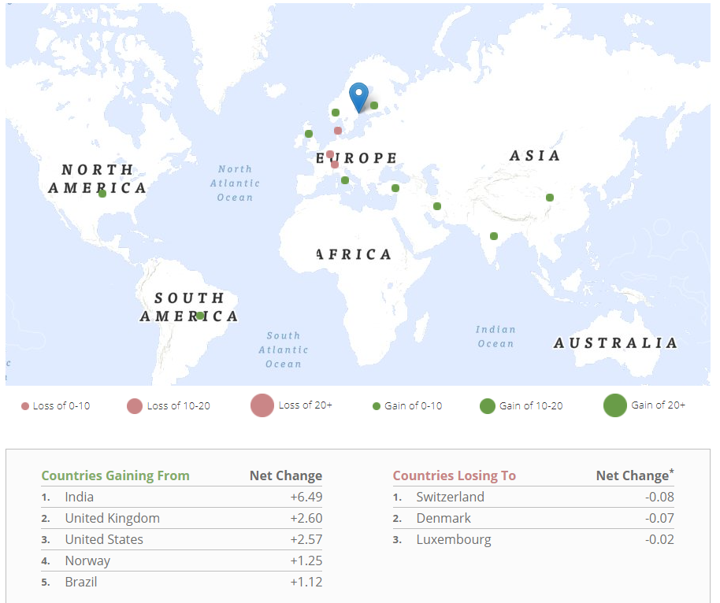